# Topic 04 - Sentiment Analysis II

Julia Parish

2022-04-26

# Sentiment Analyis II

This text sentiment analysis was completed as an assignment for the course, Environmental Data Science 231: Text and Sentiment Analysis for Environmental Problems. The data was sourced from Twitter.

Original assignment instructions can be found [here](https://maro406.github.io/EDS_231-text-sentiment/topic_4.html)

### Load Libraries

```r
library(quanteda)
library(quanteda.sentiment)
library(quanteda.textstats)
library(tidyverse)
library(tidytext)
library(lubridate)
library(wordcloud)
library(reshape2)
library(here)
library(rtweet)
library(paletteer)
library(kableExtra)
library(sentimentr)
```

## Load IPPC tweet data & create plot of data

```r
raw_tweets <- read.csv("data/IPCC_tweets_April1-10_sample.csv")

dat<- raw_tweets[,c(4,6)] # Extract Date and Title fields

tweets <- tibble(id = seq(1:length(dat$Title)),
                 date = as.Date(dat$Date,'%m/%d/%y'),
                 text = dat$Title)

head(tweets$text, n = 10)
```

```
##  [1] "thank you, followers, for the great photo suggestions for our upcoming IPCC report - on Monday you will find the lucky one selected for our cover from among your submissions!\n\nwe now need a good picture on #biofuels . any suggestions please for which we can get copyrights fast?"
##  [2] "Greenpeace: The real solution to the climate crisis will require a rapid transition away from fossil fuels. \n\nWhat else we expect from the upcoming #IPCC report on climate solutions, set for publication on Monday, 4 April ⬇️  https://t.co/EC6a25S7tY"
##  [3] "Governments have a responsibility to ensure that #IPCCReport is grounded in rapid phaseout of fossil fuel use and production — not #FalseClimateSolutions. \n\nRead more in our open letter: https://t.co/4larBPgeba https://t.co/Fv1OphPmac"
##  [4] "Next week, the IPCC will publish a new report detailing their new models and policy pathways. \n\nWant to study up before the headlines? Read @bertrandhb's second long read on CCS, explaining how and why IPCC models use so much saviour tech.\n\nhttps://t.co/6yBf0j7UWA"
##  [5] "Live stream of virtual IPCC press conference releasing the report on mitigation of climate change, 9 a.m. GMT o... https://t.co/IqRCvvQxyX"
##  [6] "Attention journalists: The deadline for embargoed materials for the upcoming @IPCC_CH report on climate mitigation has been extended to TODAY at 5:59 pm EDT. Register here: https://t.co/fLc4eHcOmm https://t.co/0eIlPb21kz"
##  [7] "The IPCC Report and “The Physics of Climate Change” https://t.co/xnxP3fup2a"
##  [8] "With time running short and most of the Summary for Policymakers yet to be approved, #IPCC Working Group III added a fourth plenary to Thursday’s packed schedule in an attempt to make headway.\n\nMore ➡️ https://t.co/CRKNFzykYE\n\n#ClimateChange #AR6 #ClimateReport https://t.co/EoaasmOEZf"
##  [9] "A helpful perspective on how to talk about the scenarios discussed in the forthcoming IPCC report https://t.co/Kpiim9NgNw"
## [10] "The private sector is an integral component of the water cycle and has much to lose as critical climate and water risks grow. \n\nThis presents an opportunity for collective action, writes Kirsten James of the sustainability nonprofit @CeresNews.  \n\nhttps://t.co/pC3kiJ6R1t"
```

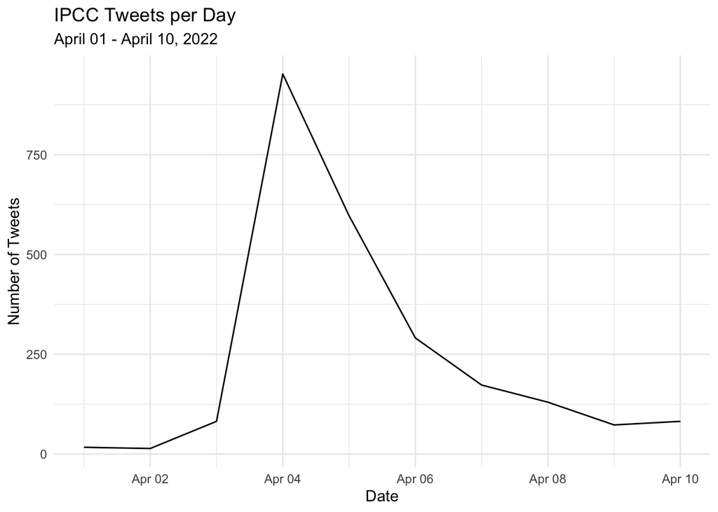

```r
#simple plot of tweets per day
tweets %>%
  count(date) %>%
  ggplot(aes(x = date, y = n))+
  geom_line() +
  labs(title = "IPCC Tweets per Day",
       subtitle = "April 01 - April 10, 2022",
       x = "Date",
       y = "Number of Tweets") +
  theme_minimal()
```

# Questions

## 1. Think about how to further clean a twitter data set. Let’s assume that the mentions of twitter accounts is not useful to us. Remove them from the text field of the tweets tibble.

```r
# keep original text column to track changes
tweets_clean <- tweets %>%
  mutate(text_clean = text)

# remove mentions and website links
tweets_clean$text_clean <- str_remove(tweets_clean$text_clean, "@[a-z,A-Z]*")

tweets_clean$text_clean <- str_remove(tweets_clean$text_clean, "[:digit:]")

tweets_clean$text_clean <- gsub("http.*","", tweets_clean$text_clean)

tweets_clean$text_clean <- gsub("https.*","", tweets_clean$text_clean)

# remove punctuations
tweets_clean$text_clean <- gsub('[[:punct:]]', '', tweets_clean$text_clean)

#tokenise tweets and remove stop words
words <- tweets_clean %>%
  select(id, date, text, text_clean) %>%
  unnest_tokens(output = word, input = text_clean, token = "words") %>%
  anti_join(stop_words, by = "word")

#clean tokens
# remove numbers
clean_tokens <- str_remove_all(words$word, "[:digit:]")

# remove mentions
clean_tokens <- str_remove_all(clean_tokens, "@[a-z,A-Z]*")

# remove apostrophes
clean_tokens <- gsub("’s", '', clean_tokens)

# remove unnecessary twitter formats
clean_tokens <- str_remove_all(clean_tokens, "t.co")

# stem the token "ipcc" as there are some plural instances
clean_tokens <- str_replace_all(string = clean_tokens,
                                pattern = "ipcc[a-z, A-Z]*",
                                replacement = "ipcc")


# stem the token "fuel" as it may occur in the plural form
clean_tokens <- str_replace_all(string = clean_tokens,
                                pattern = "fuel[a-z, A-Z]*",
                                replacement = "fuel")

# stem the token "biofuel" as it may occur in the plural form
clean_tokens <- str_replace_all(string = clean_tokens,
                                pattern = "biofuel[a-z, A-Z]*",
                                replacement = "biofuel")

# stem the token "headline" as it may occur in the plural form
clean_tokens <- str_replace_all(string = clean_tokens,
                                pattern = "headline[a-z, A-Z]*",
                                replacement = "headline")

# stem the token "regulation" as it may occur in the plural form
clean_tokens <- str_replace_all(string = clean_tokens,
                                pattern = "regulation[a-z, A-Z]*",
                                replacement = "regulation")

# stem the token "follower" as it may occur in the plural form
clean_tokens <- str_replace_all(string = clean_tokens,
                                pattern = "follower[a-z, A-Z]*",
                                replacement = "follower")

# stem the token "suggestion" as it may occur in the plural form
clean_tokens <- str_replace_all(string = clean_tokens,
                                pattern = "suggestion[a-z, A-Z]*",
                                replacement = "suggestion")

# stem the token "solution" as it may occur in the plural form
clean_tokens <- str_replace_all(string = clean_tokens,
                                pattern = "solution[a-z, A-Z]*",
                                replacement = "solution")

# stem the token "reduction" as it may occur in the plural form
clean_tokens <- str_replace_all(string = clean_tokens,
                                pattern = "reduction[a-z, A-Z]*",
                                replacement = "reduction")

# stem the token "risk" as it may occur in the plural form
clean_tokens <- str_replace_all(string = clean_tokens,
                                pattern = "risk[a-z, A-Z]*",
                                replacement = "risk")

# stem the token "scenario" as it may occur in the plural form
clean_tokens <- str_replace_all(string = clean_tokens,
                                pattern = "scenario[a-z, A-Z]*",
                                replacement = "scenario")

# stem the token "submission" as it may occur in the plural form
clean_tokens <- str_replace_all(string = clean_tokens,
                                pattern = "submission[a-z, A-Z]*",
                                replacement = "submission")

words$clean <- clean_tokens

# remove the empty strings
tib <-subset(words, clean != "")

#reassign
words <- tib

head(words)
```

```
## # A tibble: 6 × 5
##      id date       text                                              word  clean
##   <int> <date>     <chr>                                             <chr> <chr>
## 1     1 2022-04-01 "thank you, followers, for the great photo sugge… foll… foll…
## 2     1 2022-04-01 "thank you, followers, for the great photo sugge… photo photo
## 3     1 2022-04-01 "thank you, followers, for the great photo sugge… sugg… sugg…
## 4     1 2022-04-01 "thank you, followers, for the great photo sugge… upco… upco…
## 5     1 2022-04-01 "thank you, followers, for the great photo sugge… ipcc  ipcc
## 6     1 2022-04-01 "thank you, followers, for the great photo sugge… repo… repo…
```

## 2. Compare the ten most common terms in the tweets per day. Do you notice anything interesting?

```r
words_freq <- words %>%
  group_by(clean) %>%
  summarise(n()) %>%
  top_n(10) %>%
  rename("freq" = "n()") %>%
  select(clean)

words_top10 <- inner_join(words_freq, words, by = "clean") %>%
  group_by(date, clean) %>%
  summarize(n()) %>%
  rename("freq" = "n()")
```

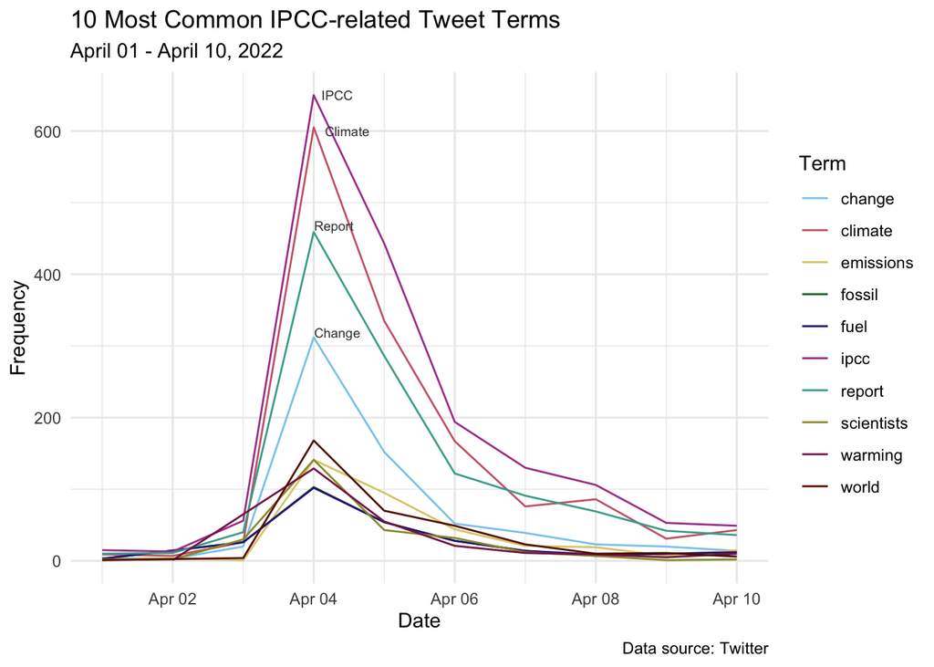

10 Most Common IPCC-related Tweet Terms

```r
top10term_plot <- ggplot(data = words_top10, aes(x = date, y = freq)) +
  geom_line(aes(color = clean)) +
  geom_text(data=words_top10[34,], y = 325, label="Change", vjust=1, hjust=-0.01,
            size = 2.5, color = "grey24") +
  geom_text(data=words_top10[34,], y = 475, label="Report",vjust=1, hjust=-0.01,
            size = 2.5, color = "grey24") +
  geom_text(data=words_top10[34,], y = 600, label="Climate", hjust=-0.25,
            size = 2.5, color = "grey24") +
    geom_text(data=words_top10[34,], y = 650, label="IPCC", hjust=-0.25,
            size = 2.5, color = "grey24") +
  labs(title = "10 Most Common IPCC-related Tweet Terms",
       subtitle = "April 01 - April 10, 2022",
       caption = "Data source: Twitter",
       x = "Date",
       y = "Frequency",
       color = "Term") +
  scale_color_paletteer_d("rcartocolor::Safe") +
  theme_minimal()

top10term_plot
```

```r
top10term_table = aggregate(words_top10$clean,
                            list(words_top10$date), paste, collapse=", ") %>%
  rename(Date = Group.1) %>%
  rename(top_words = x) %>%
  kable(col.names = c("Date", "Top 10 Words")) %>%
  kable_paper(full_width = TRUE)

top10term_table
```

| Date | Top 10 Words |
| --- | --- |
| 2022-04-01 | change, climate, emissions, fossil, fuel, ipcc, report, scientists, world |
| 2022-04-02 | change, climate, emissions, ipcc, report, scientists, warming |
| 2022-04-03 | change, climate, emissions, fossil, fuel, ipcc, report, scientists, world |
| 2022-04-04 | change, climate, emissions, fossil, fuel, ipcc, report, scientists, warming, world |
| 2022-04-05 | change, climate, emissions, fossil, fuel, ipcc, report, scientists, warming, world |
| 2022-04-06 | change, climate, emissions, fossil, fuel, ipcc, report, scientists, warming, world |
| 2022-04-07 | change, climate, emissions, fossil, fuel, ipcc, report, scientists, warming, world |
| 2022-04-08 | change, climate, emissions, fossil, fuel, ipcc, report, scientists, warming, world |
| 2022-04-09 | change, climate, emissions, fossil, fuel, ipcc, report, scientists, warming, world |
| 2022-04-10 | change, climate, emissions, fossil, fuel, ipcc, report, scientists, warming, world |

## 3. Adjust the wordcloud in the “wordcloud” chunk by coloring the positive and negative words so they are identifiable.

```r
#load sentiment lexicons
bing_sent <- get_sentiments('bing')
nrc_sent <- get_sentiments('nrc')
```

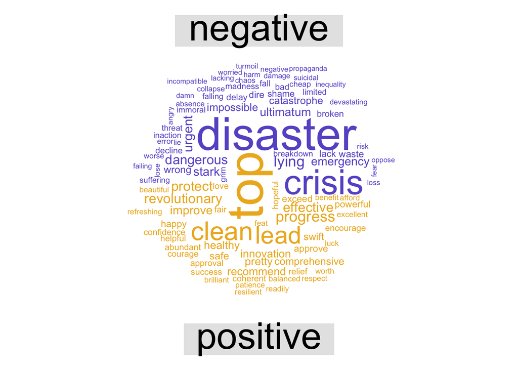

Sentiment word cloud of IPCC-related Tweet Terms between April 01 - April 10, 2022. Positive sentiment terms are identified in the yellow hue, while negative terms are purple.

```r
cloud <- words %>% inner_join(get_sentiments("bing")) %>%
  inner_join(get_sentiments("nrc")) %>%
  count(word, sentiment, sort = TRUE) %>%
  acast(word ~ sentiment, value.var = "n", fill = 0) %>%
  comparison.cloud(colors = c("slateblue3", "goldenrod2"),
                   max.words = 100)
```

```r
cloud
```

## 4. Let’s say we are interested in the most prominent entities in the Twitter discussion. Which are the top 10 most tagged accounts in the data set. Hint: the “explore_hashtags” chunk is a good starting point.

```r
corpus <- corpus(dat$Title) #enter quanteda
#summary(corpus)
# text: tweet ID, Types: species words, Tokens: total words
```

```r
tagged_accts <- tokens(corpus, remove_punct = TRUE) %>%
               tokens_keep(pattern = "@*")

# feature matrix - shows location of each features in the corpus aka located in the tweet : document feature matrix
dfm_tags<- dfm(tagged_accts)

# frequency of hashtags
tstat_freq <- textstat_frequency(dfm_tags, n = 100)
head(tstat_freq, 10)
```

```
##             feature frequency rank docfreq group
## 1          @ipcc_ch       131    1     131   all
## 2   @logicalindians        38    2      38   all
## 3  @antonioguterres        16    3      16   all
## 4          @nytimes        14    4      14   all
## 5            @yahoo        14    4      14   all
## 6            @potus        13    6      13   all
## 7               @un        12    7      12   all
## 8          @youtube        11    8      11   all
## 9  @conversationedu        10    9      10   all
## 10            @ipcc         9   10       9   all
```

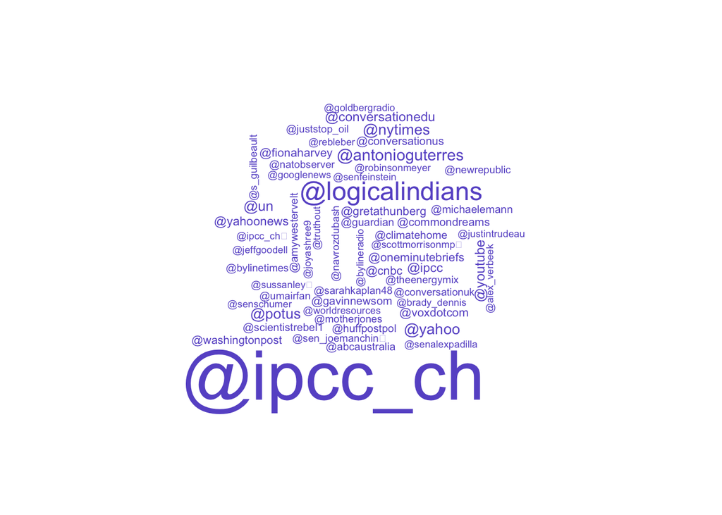

Word cloud of IPCC-related Twitter accounts tagged between April 01 - April 10, 2022.

```r
#tidytext gives us tools to convert to tidy from non-tidy formats
tags_tib <- tidy(dfm_tags)

tags_tib %>%
   count(term) %>%
   with(wordcloud(term, n, color = "slateblue3", max.words = 100))
```

```r
top_tags <- tags_tib %>%
  group_by(term) %>%
  summarize(n()) %>%
  rename("freq" = "n()") %>%
  top_n(10)
```

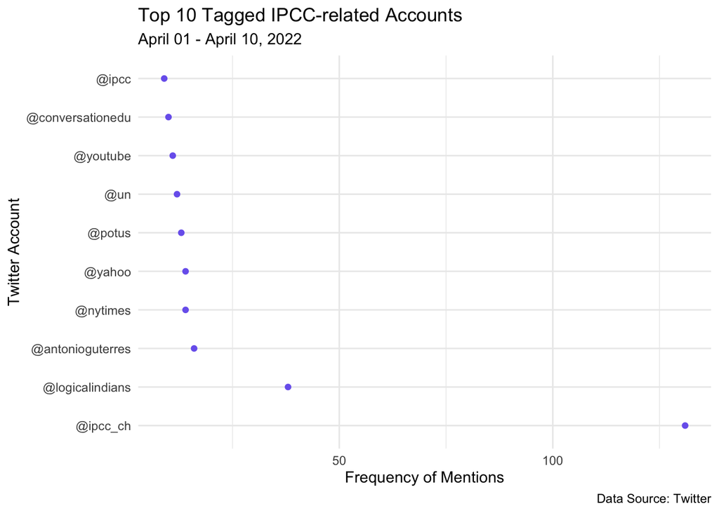

Top 10 Twitter Accounts tagged in IPCC related tweets between April 1 - April 10, 2022

```r
top10user_plot <- top_tags %>%
  mutate(term = fct_relevel(term,
            "@ipcc_ch", "@logicalindians", "@antonioguterres", "@nytimes", "@yahoo", "@potus", "@un", "@youtube", "@conversationedu", "@ipcc")) %>%
  ggplot(aes(x = freq, y = term)) +
  geom_point(color = "slateblue2") +
  labs(title = "Top 10 Tagged IPCC-related Accounts",
       subtitle = "April 01 - April 10, 2022",
       x = "Frequency of Mentions",
       y = "Twitter Account",
       caption = "Data Source: Twitter") +
  theme_minimal()

top10user_plot
```

## 5. The Twitter data download comes with a variable called “Sentiment” that must be calculated by Brandwatch. Use your own method to assign each tweet a polarity score (Positive, Negative, Neutral) and compare your classification to Brandwatch’s (hint: you’ll need to revisit the “raw_tweets” data frame).

```r
# Extract Date, Title, and Sentiment fields
dat2<- raw_tweets[,c(4, 6, 10)]

tweet_sentiment <- tibble(element_id = seq(1:length(dat2$Title)),
                    date = as.Date(dat2$Date,'%m/%d/%y'),
                    text = dat2$Title,
                    brandwatch_sentiment = dat2$Sentiment)
```

```r
# clean tweets
tweet_sentiment$text <- gsub("http[^[:space:]]*", "",tweet_sentiment$text)

tweet_sentiment$text <- str_to_lower(tweet_sentiment$text)

tweet_sentiment$text <- gsub("@*", "", tweet_sentiment$text)

tweet_sentiment$text <- sentimentr::replace_emoji(tweet_sentiment$text)

tweet_sentiment$text <- sentimentr::replace_emoticon(tweet_sentiment$text)

tweet_sentiment$text <- gsub("<*>", "", tweet_sentiment$text)

tweet_sentiment$text <- str_remove_all(tweet_sentiment$text, "[:digit:]")
```

```r
# calculate tweet sentiment
tweet_sen <- sentimentr::sentiment(tweet_sentiment$text)

# calculate tweet emotion at sentence level
tweet_emotion <- sentimentr::emotion(tweet_sentiment$text)
```

```r
#join with sentence data
sentiment <- inner_join(tweet_sentiment, tweet_sen, by = "element_id") %>%
  mutate(sent_category = case_when(
    sentiment < 0 ~ "negative",
    sentiment > 0 ~ "positive",
    sentiment == 0 ~ "neutral"))
```

```r
# assign comparison b/w brandwatch and sentiment categories
sentiment2 = sentiment %>%
  mutate(comparison = case_when(
   brandwatch_sentiment == sent_category & brandwatch_sentiment == "positive" ~ "positive",
   brandwatch_sentiment == sent_category & brandwatch_sentiment == "negative" ~ "negative",
   brandwatch_sentiment == sent_category & brandwatch_sentiment == "neutral" ~ "neutral",
   brandwatch_sentiment != sent_category ~ "no_match"))
```

```r
sentiment3 = sentiment2 %>%
  mutate(comparison = fct_relevel(comparison, "positive", "neutral", "negative", "no_match")) %>%
  count(comparison)
```

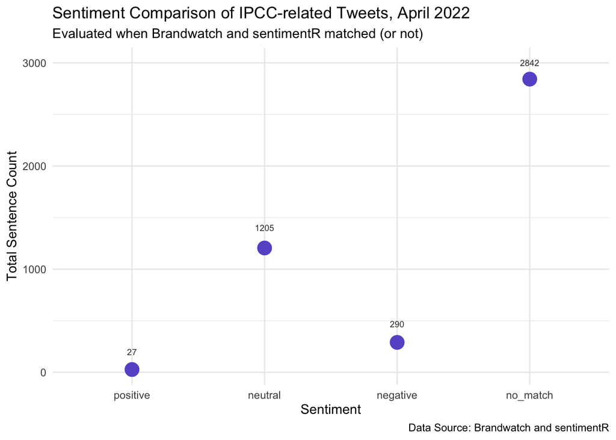

Compared two sentiment classification systems on IPCC related tweets posted between April 01 - April 10, 2022. Brandwatch sentiment and the package sentimentR were used for comparison. When the two sentiment classifcations were the same, they were designated by the polarity classification: positive, neutral, or negative. When the two classifications were not the same for a sentence, it was classified as: no_match.

```r
sent_compare_plot <- sentiment3 %>%
  ggplot(aes(x = comparison, y = n)) +
  geom_point(color = "slateblue3", size = 5) +
  geom_text(aes(x = "positive", y = 200, label = "27"), stat = "unique",
            size = 2.5, color = "grey24") +
  geom_text(aes(x = "neutral", y = 1400, label = "1205"), stat = "unique",
            size = 2.5, color = "grey24") +
  geom_text(aes(x = "negative", y = 470, label = "290"), stat = "unique",
            size = 2.5, color = "grey24") +
  geom_text(aes(x = "no_match", y = 3000, label = "2842"), stat = "unique",
            size = 2.5, color = "grey24") +
  labs(title = "Sentiment Comparison of IPCC-related Tweets, April 2022",
       subtitle = "Evaluated when Brandwatch and sentimentR matched (or not)",
       caption = "Data Source: Brandwatch and sentimentR",
       x = "Sentiment",
       y = "Total Sentence Count") +
  theme_minimal()

sent_compare_plot
```

```r
method_comparison <- sentiment %>%
  mutate(sent_comparison = case_when(
    brandwatch_sentiment == "positive" & sent_category == "positive" ~ "both positive",
    brandwatch_sentiment == "negative" & sent_category == "negative" ~ "both negative",
    brandwatch_sentiment == "neutral" & sent_category == "neutral" ~ "both neutral",
    brandwatch_sentiment == "positive" & sent_category == "negative" ~ "brandwatch positive, method 2 negative",
    brandwatch_sentiment == "positive" & sent_category == "neutral" ~ "brandwatch positive, method 2 neutral",
    brandwatch_sentiment == "neutral" & sent_category == "positive" ~ "brandwatch neutral, method 2 positive",
    brandwatch_sentiment == "neutral" & sent_category == "negative" ~ "brandwatch neutral, method 2 negative",
    brandwatch_sentiment == "negative" & sent_category == "positive" ~ "brandwatch negative, method 2 positive",
    brandwatch_sentiment == "negative" & sent_category == "neutral" ~ "brandwatch negative, method 2 neutral"))

methods_compare_counts <- method_comparison %>%
  count(sent_comparison)
```

```r
methods_compare_counts2 <-
  method_comparison %>%
  group_by(brandwatch_sentiment, sent_category) %>%
  summarise(count = n())
```

```r
n_tweets <- nrow(sentiment)

method_comparison_table <- method_comparison %>%
  count(sent_category) %>%
  mutate(percent = round((n / n_tweets) * 100, 1)) %>%
  kable(col.names = c("Comparison", "Count", "Percent")) %>%
  kable_paper(full_width = FALSE) %>%
  row_spec(c(0), background = "lightgray")
method_comparison_table
```

| Comparison | Count | Percent |
| --- | --- | --- |
| negative | 1334 | 30.6 |
| neutral | 1324 | 30.3 |
| positive | 1706 | 39.1 |

```r
both_neg <- methods_compare_counts$n[methods_compare_counts$sent_comparison == "both negative"]

both_pos <- methods_compare_counts$n[methods_compare_counts$sent_comparison == "both positive"]


both_neutral <- methods_compare_counts$n[methods_compare_counts$sent_comparison == "both neutral"]

bw_neu_meth2_pos <- methods_compare_counts$n[methods_compare_counts$sent_comparison == "brandwatch neutral, method 2 positive"]

bw_neu_meth2_neg <- methods_compare_counts$n[methods_compare_counts$sent_comparison == "brandwatch neutral, method 2 negative"]

opposite <- (methods_compare_counts$n[methods_compare_counts$sent_comparison == "brandwatch negative, method 2 positive"]) + (methods_compare_counts$n[methods_compare_counts$sent_comparison == "brandwatch positive, method 2 negative"])
```

There were 290 tweets where both methods assigned a negative sentiment, 27 tweets where both methods assigned a positive sentiment, and 1205 tweets where both methods assigned a neutral sentiment. The greatest disagreements were when brandwatch assigned a neutral sentiment but the other method assigned a positive sentiment (1567 tweets) or a negative sentiment (1039 tweets). There were 117 tweets where the two methods assigned completely opposite sentiments.

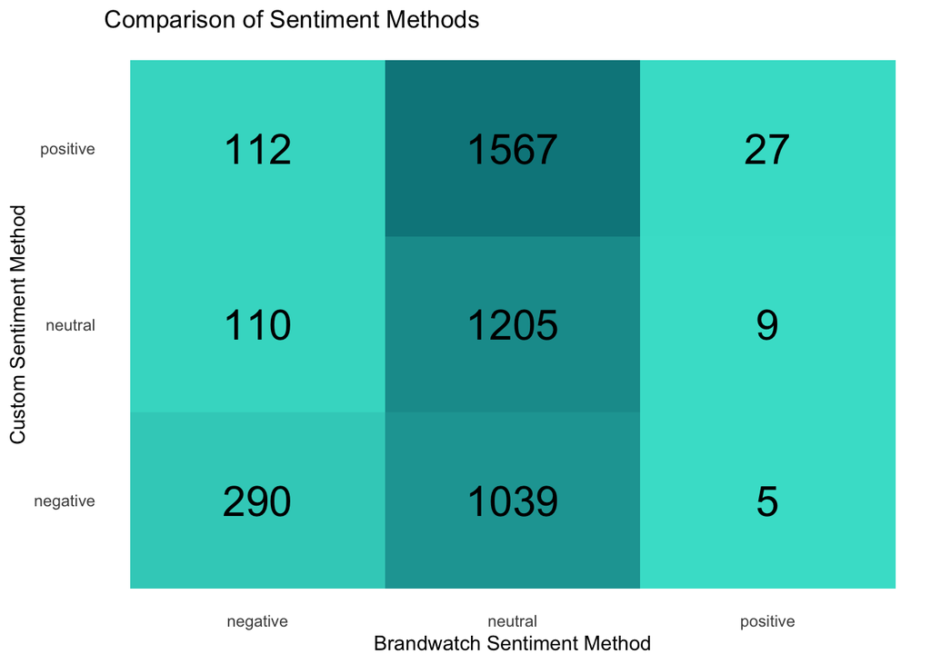

```r
ggplot(data = methods_compare_counts2, aes(x = brandwatch_sentiment, y = sent_category)) +
  geom_tile(aes(fill = count), show.legend = FALSE) +
  geom_text(aes(label = count), color = "black", size = 8) +
  theme_minimal() +
  theme(panel.grid.major = element_blank()) +
  scale_fill_gradientn(colors = c("turquoise", "turquoise4")) +
  labs(title = "Comparison of Sentiment Methods",
       x = "Brandwatch Sentiment Method",
       y = "Custom Sentiment Method")
```

## Bonus - Emoji Frequency Exploration

```r
# extract emojis from tweets
ipcc_emojis <- emojis %>%
  # for each emoji, find tweets containing this emoji
  mutate(tweet = map(code, ~grep(.x, tweets_clean$text))) %>%
  unnest(tweet) %>%
  # count the number of tweets in which each emoji was found
  count(code, description) %>%
  mutate(emoji = paste(code, description))
```

```r
plot_emoji <- ipcc_emojis %>%
  top_n(5, n) %>%
  ggplot() +
  geom_col(aes(x = fct_reorder(emoji, n), y = n, fill = n),
           color = "grey58", width = 1) +
  scale_fill_gradientn("n", colors = brewer.pal(5, "Set2")) +
  labs(x = "", y = "Count",
       title = "Most Popular Emojis in IPCC tweets",
       subtitle = "April 01 - April 10, 2022") +
  coord_flip()

plot_emoji
```

[output not shown]

```r
# save emoji plot as png
# ggsave(file = "emojiplot.png", plot = plot_emoji,
#   scale = 1, width = 6, height = 6,
#   units = "in", dpi = 300)
```